# DE_polyA_vs_pseudo

Ariel Hippen

2022-07-31

# DESeq2 pipeline

As a control for our DE analysis, we will run differential expression on our real bulk results and pseudo-bulk data (single-cell data pooled together to approximate a bulk RNA-seq sample.) Here we’ll compare to our dissociated, poly-A captured bulk data. Since that’s the same library prep process, we’d hope that there’s not a ton of significant changes here, but let’s be honest we’re probably not that lucky.

```r
suppressPackageStartupMessages({
  library(data.table)
  library(DESeq2)
  library(vsn)
  library(pheatmap)
  library(RColorBrewer)
  library(PCAtools)
  library(testit)
})

source("../../config.R")
```

## Load data

```r
# Get paths to STAR.counts files for bulk poly-A samples
# Note: variable data_path is loaded from config.R
directory <- paste(data_path, "bulk_tumors", sep = "/")
sampleFiles <- list.files(directory, recursive = TRUE, full.names = TRUE)
sampleFiles <- grep("ReadsPerGene.out.tab", sampleFiles, value=TRUE)
sampleFiles <- grep("polyA",sampleFiles, value=TRUE)
```

DESeq expects a metadata table to pass into the colData part of a SummarizedExperiment object. We’ll prep it here.

```r
# Note: variable samples is loaded from config.R
sampleNames <- c(gsub(".*/(\\d+)/.*", "\\1", sampleFiles), samples)
sampleCondition <- rep(c("bulk","pseudo"), each=8)
samplePool <- ifelse(sampleNames %in% c("2251","2428","2467","2497"),
                     "01132022","12162021")
sampleUnique <- paste(sampleNames,sampleCondition,sep="_")
colData <- data.frame(id = sampleUnique,
                      sample = sampleNames,
                      pool = samplePool,
                      condition = sampleCondition)
colData$condition <- factor(colData$condition)
```

Now we can load in the bulk files and create a counts matrix. Note that this shouldn’t be stranded data, so we’ll use column 2 of the STAR counts files.

```r
counts <- matrix(nrow=36601, ncol = 8)
for (i in 1:8){
  newcounts <- fread(sampleFiles[i])
  newcounts <- newcounts[-c(1:4),]
  counts[, i] <- newcounts$V2
  if (i == 1) {
    rownames(counts) <- newcounts$V1
  } else{
      assert(rownames(counts) == newcounts$V1)
  }
}
rm(newcounts); gc()
```

```
##            used  (Mb) gc trigger  (Mb) max used  (Mb)
## Ncells  7739102 413.4   12195534 651.4  9445372 504.5
## Vcells 13579761 103.7   21962302 167.6 17217563 131.4
```

And now we’ll add in the pseudobulk data from generate_pseudobulk.R.

```r
sce_path <- paste(local_data_path, "sce_objects", sep = "/")
pseudo <- readRDS(paste(sce_path, "full_pseudobulk.rds", sep = "/"))
counts <- cbind(counts, pseudo)
colnames(counts) <- colData$id
rm(pseudo); gc()
```

```
##            used  (Mb) gc trigger  (Mb) max used  (Mb)
## Ncells  7739754 413.4   12195534 651.4  9445372 504.5
## Vcells 13987034 106.8   26434762 201.7 17217563 131.4
```

This counts matrix has the genes listed by their Ensembl IDs, which is helpful for uniqueness but bad for readability in the downstream analysis. The easiest way I’ve found to convert ensembl IDs to gene names for this dataset is by loading in a SingleCellExperiment object from the same experiment, where this mapping is automatically stored.

```r
sce <- readRDS(paste(sce_path, "pooled_clustered_50.rds", sep = "/"))
gene_map <- as.data.frame(subset(rowData(sce), select=c("ID","Symbol")))
gene_map <- gene_map[rownames(counts)==gene_map$ID,]
rownames(counts) <- gene_map$Symbol
rm(sce); gc()
```

```
##            used  (Mb) gc trigger  (Mb)  max used  (Mb)
## Ncells  8166909 436.2   12195534 651.4  10325726 551.5
## Vcells 14909821 113.8  106540765 812.9 114609067 874.4
```

```r
# Create DESeq object
dds <- DESeqDataSetFromMatrix(countData = counts,
                              colData = colData,
                              #design = ~condition)
                              design = ~ sample + condition)
dds
```

```
## class: DESeqDataSet
## dim: 36601 16
## metadata(1): version
## assays(1): counts
## rownames(36601): MIR1302-2HG FAM138A ... AC007325.4 AC007325.2
## rowData names(0):
## colnames(16): 2251_bulk 2267_bulk ... 2467_pseudo 2497_pseudo
## colData names(4): id sample pool condition
```

The tutorial recommends doing some basic pre-filtering of non- or low-expressed genes to speed up computation, estimate the library depth correction factor, and to clean up later visualizations.

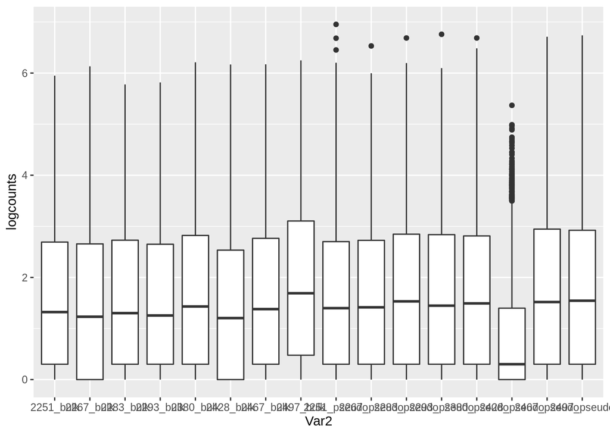

```r
colnames(counts) <- colData$id
melted_counts <- melt(counts)
melted_counts$logcounts <- log10(melted_counts$value+1)

ggplot(melted_counts, aes(x=Var2, y=logcounts)) + geom_boxplot()
```

Okay, in some of the samples at least 25% of the genes are not expressed. Let’s go a little more conservative and remove any genes that have fewer than 20 reads total.

```r
keep <- rowSums(counts(dds)) >= 20
dds <- dds[keep, ]
```

## Differential expression

```r
dds$condition <- relevel(dds$condition, ref = "bulk")
```

```r
# Run differential expression
dds <- DESeq(dds)
res <- results(dds)
res
```

```
## log2 fold change (MLE): condition pseudo vs bulk
## Wald test p-value: condition pseudo vs bulk
## DataFrame with 29073 rows and 6 columns
##              baseMean log2FoldChange     lfcSE      stat      pvalue
##             <numeric>      <numeric> <numeric> <numeric>   <numeric>
## MIR1302-2HG   1.62902      -3.980546  2.092308 -1.902466 0.057110260
## AL627309.1    7.92086       0.506227  0.428939  1.180184 0.237927211
## AL627309.2    1.20480      -3.115491  2.308855 -1.349366 0.177219431
## AL627309.5   89.09261       0.118485  0.242141  0.489324 0.624612156
## AP006222.2    6.32065      -3.455642  0.945307 -3.655578 0.000256604
## ...               ...            ...       ...       ...         ...
## AC136352.3   0.925265        1.37095  3.018668  0.454157 6.49716e-01
## AC136616.1  17.352731       -1.41599  0.513073 -2.759824 5.78325e-03
## AC141272.1   4.707978       -3.02484  1.010293 -2.994026 2.75322e-03
## AC007325.4  57.207674        2.43936  0.275606  8.850901 8.68155e-19
## AC007325.2   9.527420       -3.85729  0.608661 -6.337342 2.33763e-10
##                    padj
##               <numeric>
## MIR1302-2HG 0.083971406
## AL627309.1  0.300345525
## AL627309.2  0.231772403
## AL627309.5  0.684431977
## AP006222.2  0.000548708
## ...                 ...
## AC136352.3  7.06849e-01
## AC136616.1  1.02068e-02
## AC141272.1  5.10292e-03
## AC007325.4  5.75071e-18
## AC007325.2  9.00874e-10
```

The tutorial says “shrinkage of effect size (LFC estimates) is useful for visualization and ranking of genes. To shrink the LFC, we pass the dds object to the function lfcShrink. We provide the dds object and the name or number of the coefficient we want to shrink.”

```r
resLFC <- lfcShrink(dds, coef="condition_pseudo_vs_bulk", type="apeglm")
resLFC
```

```
## log2 fold change (MAP): condition pseudo vs bulk
## Wald test p-value: condition pseudo vs bulk
## DataFrame with 29073 rows and 5 columns
##              baseMean log2FoldChange     lfcSE      pvalue        padj
##             <numeric>      <numeric> <numeric>   <numeric>   <numeric>
## MIR1302-2HG   1.62902      -0.677142  1.366828 0.057110260 0.083971406
## AL627309.1    7.92086       0.406853  0.410123 0.237927211 0.300345525
## AL627309.2    1.20480      -0.477567  1.172574 0.177219431 0.231772403
## AL627309.5   89.09261       0.112368  0.238653 0.624612156 0.684431977
## AP006222.2    6.32065      -2.867605  1.250681 0.000256604 0.000548708
## ...               ...            ...       ...         ...         ...
## AC136352.3   0.925265       0.100295  1.013510 6.49716e-01 7.06849e-01
## AC136616.1  17.352731      -1.211904  0.532641 5.78325e-03 1.02068e-02
## AC141272.1   4.707978      -2.635685  1.424880 2.75322e-03 5.10292e-03
## AC007325.4  57.207674       2.392624  0.280239 8.68155e-19 5.75071e-18
## AC007325.2   9.527420      -3.750043  0.640417 2.33763e-10 9.00874e-10
```

A quick summary of our differential expression results, at both a 0.1 and 0.05 FDR.

```r
summary(res)
```

```
##
## out of 29073 with nonzero total read count
## adjusted p-value < 0.1
## LFC > 0 (up)       : 9402, 32%
## LFC < 0 (down)     : 10750, 37%
## outliers [1]       : 0, 0%
## low counts [2]     : 0, 0%
## (mean count < 1)
## [1] see 'cooksCutoff' argument of ?results
## [2] see 'independentFiltering' argument of ?results
```

```r
sum(res$padj  < 0.1, na.rm = TRUE)
```

```
## [1] 20152
```

```r
res05 <- results(dds, alpha=0.05)
summary(res05)
```

```
##
## out of 29073 with nonzero total read count
## adjusted p-value < 0.05
## LFC > 0 (up)       : 8755, 30%
## LFC < 0 (down)     : 10040, 35%
## outliers [1]       : 0, 0%
## low counts [2]     : 0, 0%
## (mean count < 1)
## [1] see 'cooksCutoff' argument of ?results
## [2] see 'independentFiltering' argument of ?results
```

```r
sum(res05$padj < 0.05, na.rm = TRUE)
```

```
## [1] 18795
```

So it seems like there are more genes downregulated than up (meaning there are more genes more highly expressed in true bulk than in pseudobulk). This is what we’d expect, given the technical dropouts of scRNA-seq, but it’s worth noting there’s still a *lot* of genes upregulated, aka more expressed in pseudobulk than in true bulk.

### Plotting results

From tutorial: “In DESeq2, the function plotMA shows the log2 fold changes attributable to a given variable over the mean of normalized counts for all the samples in the DESeqDataSet. Points will be colored blue if the adjusted p value is less than 0.1. Points which fall out of the window are plotted as open triangles pointing either up or down.”

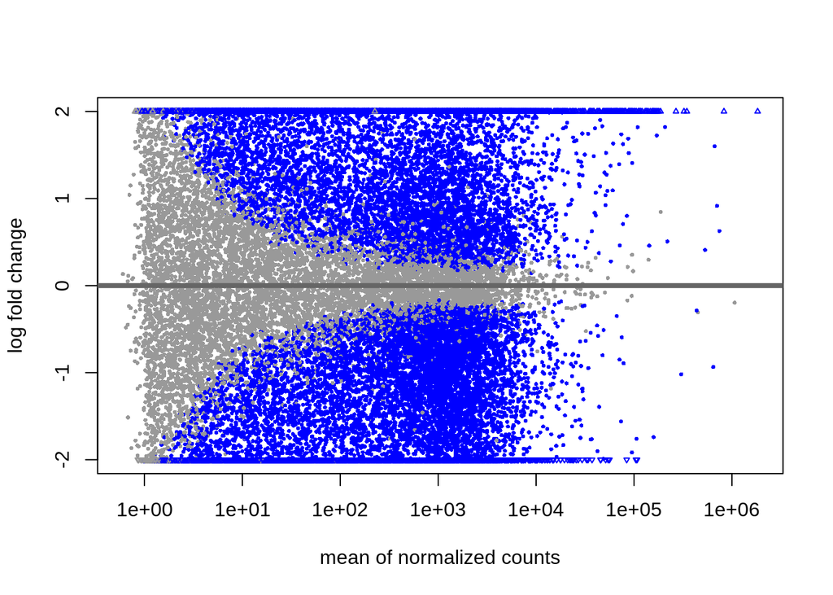

```r
plotMA(res, ylim=c(-2,2))
```

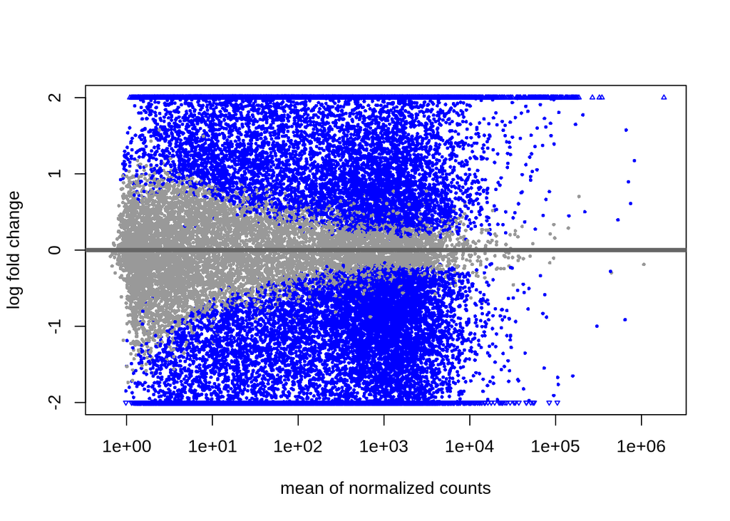

```r
plotMA(resLFC, ylim=c(-2,2))
```

### Transformations

The DESeq2 authors recommend the rlog method to adjust for heteroskedasticity in experiments with n < 30. We’ll check it and the other vst method they recommend for n > 30.

```r
vsd <- vst(dds, blind=FALSE)
rld <- rlog(dds, blind=FALSE)
```

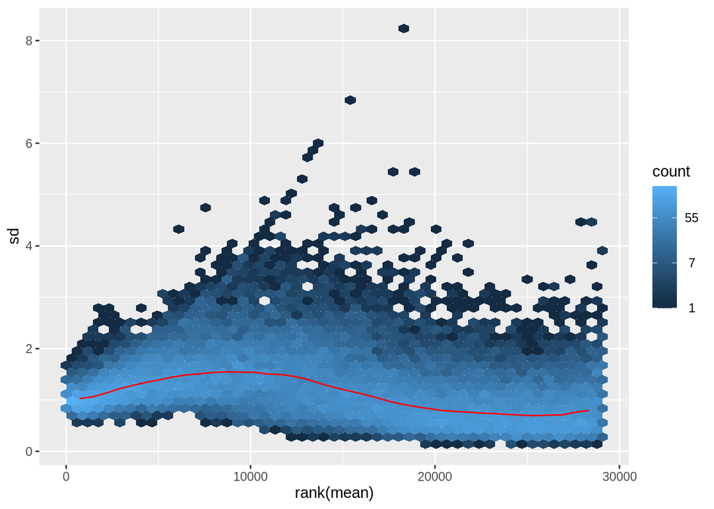

```r
ntd <- normTransform(dds)
meanSdPlot(assay(ntd))
```

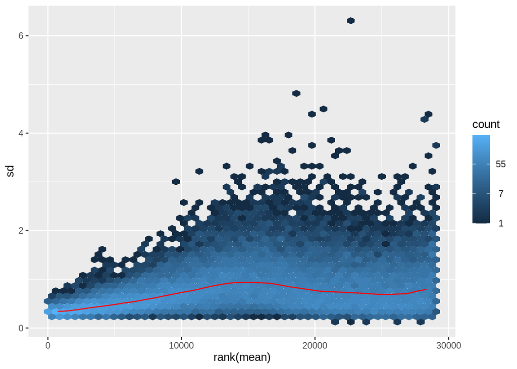

```r
meanSdPlot(assay(vsd))
```

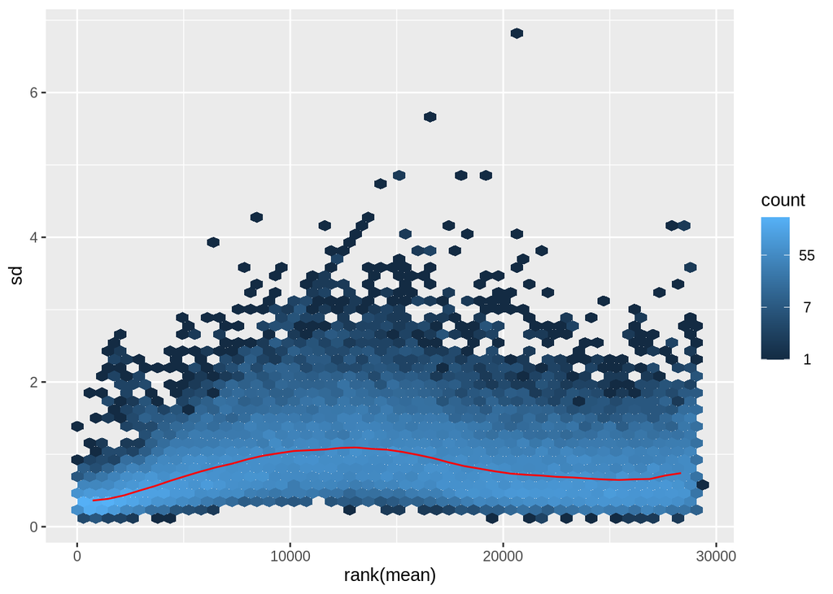

```r
meanSdPlot(assay(rld))
```

## Sample comparisons

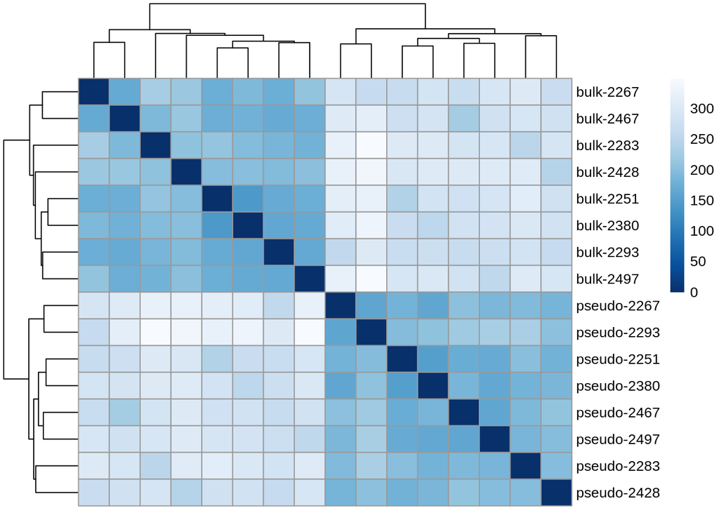

```r
sampleDists <- dist(t(assay(rld)))

sampleDistMatrix <- as.matrix(sampleDists)
rownames(sampleDistMatrix) <- paste(rld$condition, rld$sample, sep="-")
colnames(sampleDistMatrix) <- NULL
colors <- colorRampPalette( rev(brewer.pal(9, "Blues")) )(255)
pheatmap(sampleDistMatrix,
         clustering_distance_rows=sampleDists,
         clustering_distance_cols=sampleDists,
         col=colors)
```

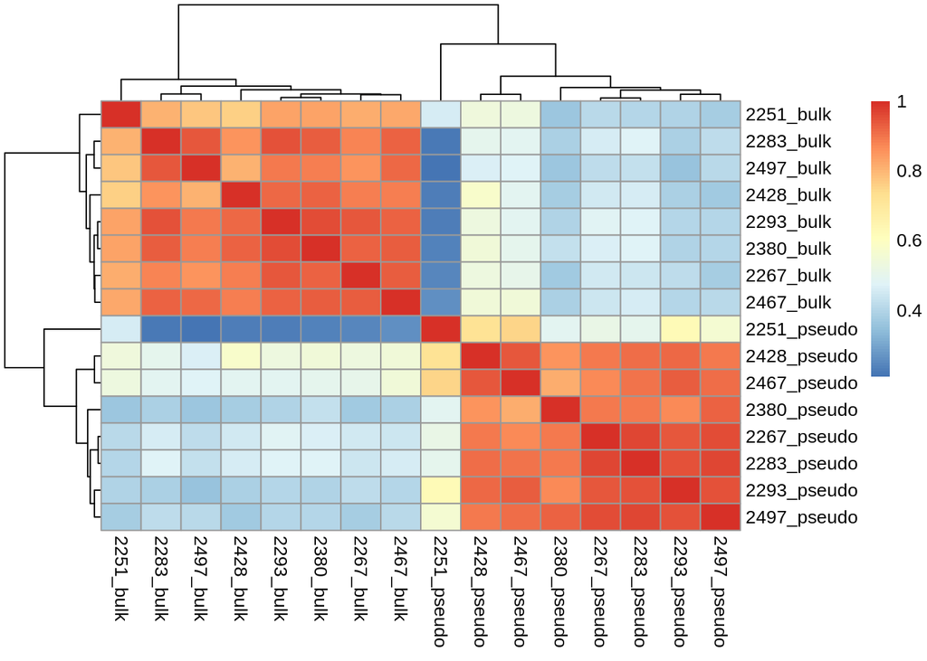

```r
x<-cor(counts)
pheatmap(x)
```

The separation is clearly sequencing type-specific.

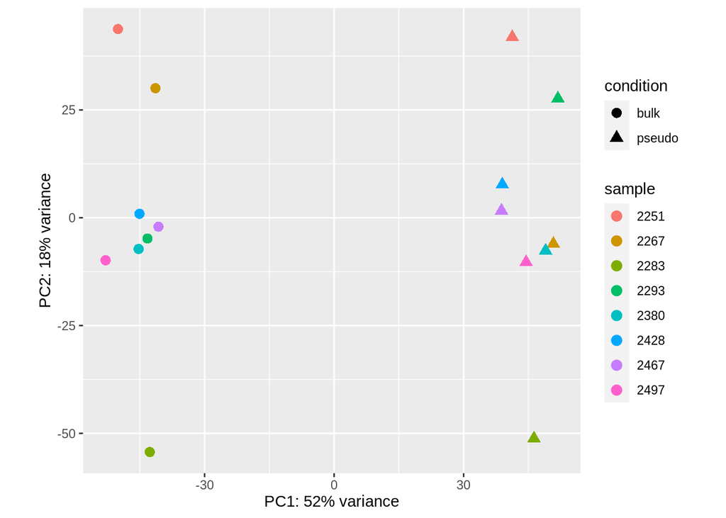

```r
pcaData <- plotPCA(rld, intgroup=c("condition", "sample"), returnData=TRUE)
percentVar <- round(100 * attr(pcaData, "percentVar"))
ggplot(pcaData, aes(PC1, PC2, color=sample, shape=condition)) +
  geom_point(size=3) +
  xlab(paste0("PC1: ",percentVar[1],"% variance")) +
  ylab(paste0("PC2: ",percentVar[2],"% variance")) +
  coord_fixed()
```

Okay, it’s clear that PC1 is sequencing type.

For thoroughness, I’m going to check and see if sequencing is represented in PCs 3-5. I’m going to use the PCAtools tutorial (https://bioconductor.org/packages/release/bioc/vignettes/PCAtools/inst/doc/PCAtools.html) for this.

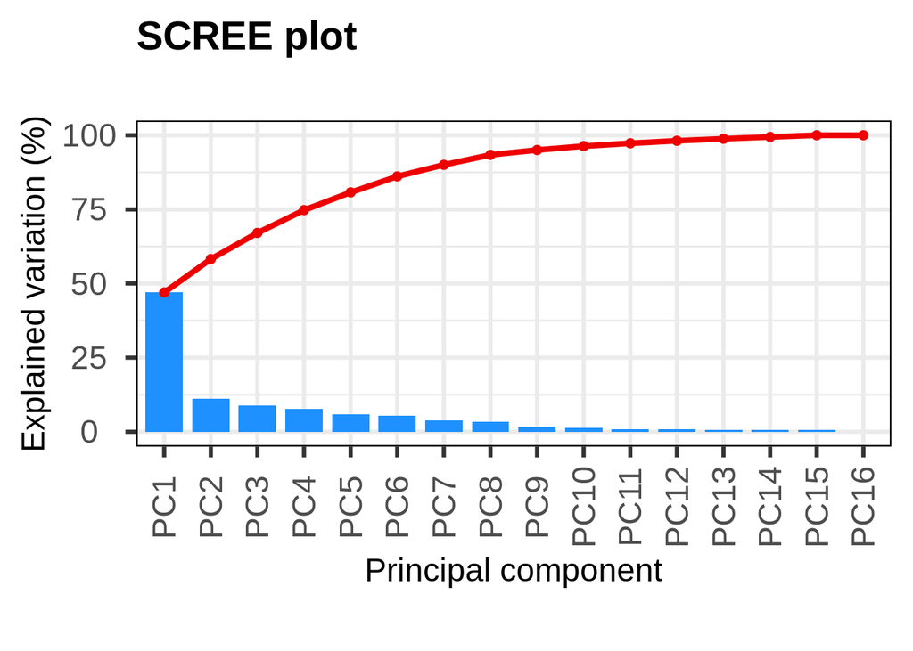

```r
p <- pca(assay(rld), metadata = colData(rld), removeVar = 0.1)
screeplot(p, axisLabSize = 18, titleLabSize = 22)
```

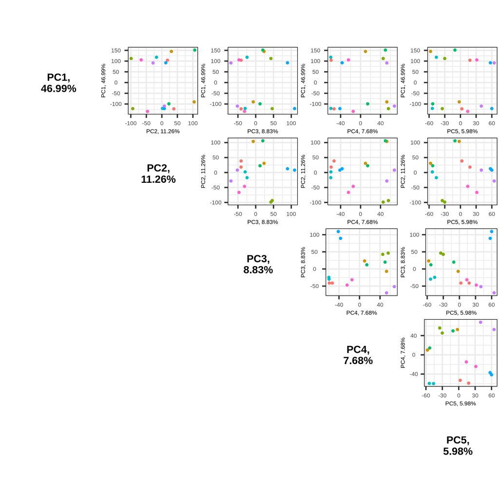

```r
pairsplot(p, colby = "sample", pointSize=2)
```

Okay, PCs 2-5 seem to be roughly based on sample, but the overwhelming distinction is sequencing type.

## Conclusions

The sequencing type seems to have such a big effect that I’m not sure we can really use pseudobulk as a control for differential expression. This is disappointing, but it may actually be a useful result to remind about the perils of using single-cell data for deconvolution. It’s also a little surprising that there is significant differential expression in both directions, so this isn’t just a factor of technical dropouts.

```r
# Save data
deseq_path <- paste(local_data_path, "deseq2_output", sep = "/")
saveRDS(dds, file = paste(deseq_path, "polyA_vs_pseudo_data.rds", sep = "/"))

# Save results files
saveRDS(res, file = paste(deseq_path, "polyA_vs_pseudo_FDR_0.1.rds", sep = "/"))
saveRDS(res05, file = paste(deseq_path, "polyA_vs_pseudo_FDR_0.05.rds", sep = "/"))
```